# Value Imputation

*I'm a substitute for another guy*  
*I look pretty tall but my heels are high*  
*The simple things you see are all complicated*  
*I look pretty young, but I'm just back-dated, yeah*

–Pete Townsend

- Do you have *a lot* of data?
- Do you have knowledge or suspicion that missing data occurs in a biased way?
- Do your records have many or few features?
- What is the role of the missing value?

## Typical-value Imputation

*And there's another marketing ploy*  
*Typical girl gets the typical boy*

–Ari Up, Paloma McLardy, Tessa Pollitt, and Viv Albertine

## Typical Tabular Data

```python
GT(df.iloc[:, [10, 0, 1, 2, 3, 15, -2, -1]].sample(10))
```

| family history | erythema | scaling | definite borders | itching | exocytosis | Age | TARGET |
| --- | --- | --- | --- | --- | --- | --- | --- |
| 0 | 2 | 2 | 2 | 0 | 0 | 62 | psoriasis |
| 0 | 2 | 2 | 2 | 2 | 3 | 44 | lichen planus |
| 0 | 3 | 2 | 0 | 1 | 3 | 30 | seboreic dermatitis |
| 0 | 3 | 2 | 2 | 2 | 2 | 22 | lichen planus |
| 0 | 3 | 2 | 2 | 1 | 1 | 47 | seboreic dermatitis |
| 0 | 2 | 1 | 1 | 3 | 0 | 19 | cronic dermatitis |
| 0 | 2 | 3 | 2 | 0 | 0 | 33 | psoriasis |
| 0 | 3 | 2 | 0 | 3 | 3 | 52 | seboreic dermatitis |
| 0 | 2 | 2 | 2 | 1 | 2 | 25 | seboreic dermatitis |
| 0 | 2 | 3 | 2 | 0 | 2 | 41 | seboreic dermatitis |

```python
clean, suspicious = [], {}
for col in df.columns:
    values = df[col].unique()
    if set(values) <= {0, 1, 2, 3}:
        clean.append(col)
    else:
        suspicious[col] = values
```

```python
print(f"Not 0-3 ordinal: {', '.join(suspicious)}")
print(f"Ordinal values:\n  {'\n  '.join(clean[:8])}")
print(f"  ... {len(clean)-8} other fields")
```

```
Not 0-3 ordinal: Age, TARGET
Ordinal values:
  erythema
  scaling
  definite borders
  itching
  koebner phenomenon
  polygonal papules
  follicular papules
  oral mucosal involvement
  ... 25 other fields
```

```python
# Assign missing ages marked with '?' as None
df_v2 = df.copy()
df_v2.loc[df.Age == '?', 'Age'] = None
df_v2['Age'] = df_v2.Age.astype(float)
# Display those rows with missing ages
GT(df_v2
     .loc[df_v2.Age.isnull()]
     .iloc[:6, [10, 0, 1, 2, 3, -2, -1]])
```

| family history | erythema | scaling | definite borders | itching | Age | TARGET |
| --- | --- | --- | --- | --- | --- | --- |
| 1 | 2 | 2 | 1 | 0 |  | psoriasis |
| 0 | 2 | 1 | 0 | 0 |  | pityriasis rosea |
| 0 | 2 | 2 | 1 | 2 |  | seboreic dermatitis |
| 1 | 2 | 1 | 2 | 3 |  | lichen planus |
| 0 | 2 | 1 | 0 | 2 |  | cronic dermatitis |
| 0 | 1 | 1 | 1 | 3 |  | cronic dermatitis |

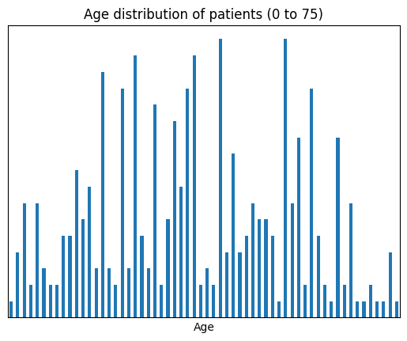

```python
(df_v2.Age
   .value_counts()
   .sort_index()
   .plot(kind="bar", yticks=[], xticks=[],
         title="Age distribution of patients "
               f"({df_v2.Age.min():.0f} to {df_v2.Age.max():.0f})"));
```

```python
df_v2.Age.mean().round(), df_v2.Age.median()
```

```
(36.0, 35.0)
```

```python
df_v2.Age.mode()
```

```
0    40.0
1    50.0
Name: Age, dtype: float64
```

| Year | Median Age | Year | Median Age |  |
| --- | --- | --- | --- | --- |
| 1950 | 19.7 | 1990 | 21.7 |  |
| 1955 | 19.4 | 1995 | 23.0 |  |
| 1960 | 19.6 | 2000 | 24.5 |  |
| 1965 | 18.4 | 2005 | 26.4 |  |
| 1970 | 18.5 | 2010 | 28.2 |  |
| 1975 | 19.1 | 2015 | 29.8 |  |
| 1980 | 19.5 | 2020 | 31.6 |  |
| 1985 | 20.5 |  |  |  |

```python
df_v3 = df_v2.copy()
df_v3.loc[df_v3.Age.isnull(), 'Age'] = df_v3.Age.median()
df_v3.Age.value_counts().head(10)
```

```
Age
35.0    22
40.0    17
50.0    17
27.0    16
36.0    16
22.0    15
55.0    14
25.0    14
30.0    13
33.0    12
Name: count, dtype: int64
```

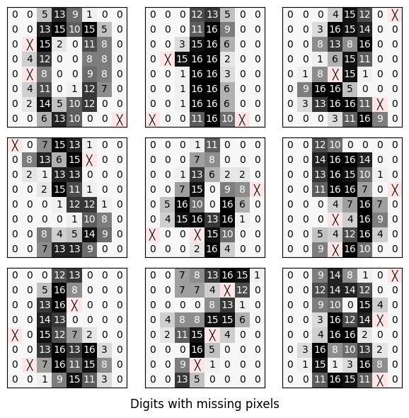

```python
show_digits(digits, title="Digits with missing pixels")
```

```python
def fill_missing(digit):
    digit = digit.copy()
    missing = np.where(digit == -1)
    for y, x in zip(*missing):  # Pull off x/y position of pixel
        # Do not want negative indices in slice
        x_start = max(0, x-1)
        y_start = max(0, y-1)
        x_end = x+2
        y_end = y+2
        # What if another -1 is in region? Remove all the -1s
        region = digit[y_start:y_end, x_start:x_end].flatten()
        region = region[region >=0]
        total = np.sum(region)
        avg = total // region.size
        digit[y, x] = avg
    return digit
```

```python
new = np.empty_like(digits)
for n in range(new.shape[0]):
    new[n] = fill_missing(digits[n])
```

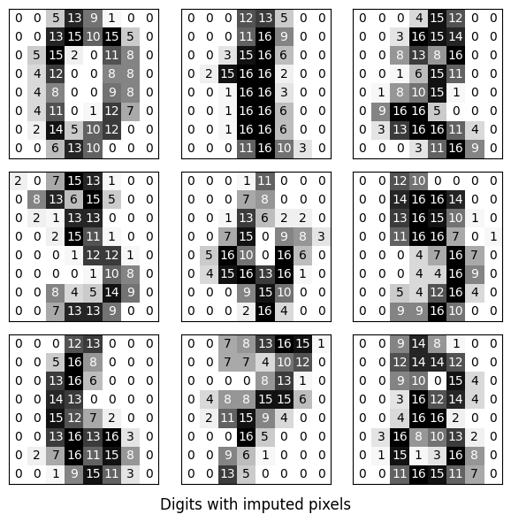

```python
show_digits(new, title="Digits with imputed pixels")
```

# Trend Imputation

*The longer you stand in line, the greater the likelihood that you are standing in the wrong line.*

–Anoynymous

## Types of Trends

- Forward/backward fill
- Local regression
- Time-sensitive regression
- Non-local regression
- Correlation imputation

```python
GT(dates)
```

| day | value |
| --- | --- |
| 2001-01-01 | -10.0 |
| 2001-01-05 | 1.0 |
| 2001-01-10 | 2.0 |
| 2001-02-01 |  |
| 2001-02-05 | 4.0 |

```python
GT(dates.ffill())  # or .bfill()
```

| day | value |
| --- | --- |
| 2001-01-01 | -10.0 |
| 2001-01-05 | 1.0 |
| 2001-01-10 | 2.0 |
| 2001-02-01 | 2.0 |
| 2001-02-05 | 4.0 |

```python
GT(dates.interpolate('linear'))
```

| day | value |
| --- | --- |
| 2001-01-01 | -10.0 |
| 2001-01-05 | 1.0 |
| 2001-01-10 | 2.0 |
| 2001-02-01 | 3.0 |
| 2001-02-05 | 4.0 |

```python
dates["value"] = dates[["value"]].interpolate('time').round(2)
GT(dates)
```

| day | value |
| --- | --- |
| 2001-01-01 | -10.0 |
| 2001-01-05 | 1.0 |
| 2001-01-10 | 2.0 |
| 2001-02-01 | 3.69 |
| 2001-02-05 | 4.0 |

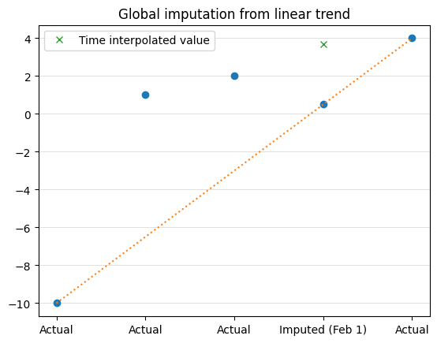

```python
plot_filled_trend(date_series)
```

```python
feat = 'follicular horn plug'
age_groups = derm.groupby(feat)[["Age"]].mean()
GT(age_groups.reset_index().round(2))
```

| follicular horn plug | Age |
| --- | --- |
| 0 | 37.7 |
| 1 | 20.4 |
| 2 | 10.62 |
| 3 | 9.75 |

```python
_derm = derm.copy()
missing = _derm.loc[derm.Age.isnull()].index
_derm.loc[missing, 'Age'] = _derm[feat].map(age_groups.Age).round(2)
GT(_derm.loc[missing, [feat, 'scaling', 'itching', 'Age']])
```

| follicular horn plug | scaling | itching | Age |
| --- | --- | --- | --- |
| 0 | 2 | 0 | 37.7 |
| 0 | 1 | 0 | 37.7 |
| 0 | 2 | 2 | 37.7 |
| 0 | 1 | 3 | 37.7 |
| 0 | 1 | 2 | 37.7 |
| 0 | 1 | 3 | 37.7 |
| 0 | 1 | 2 | 37.7 |
| 0 | 1 | 3 | 37.7 |

## A Larger Coarse Time Series

This real-world data set concerns the tax-assessed market value of each property. The data were obtained by passing an SQL query over an HTTPS interface, and getting back a JSON result. The particular query was:

```
SELECT parcel_number, year, market_value FROM assessments
```

From OpenDataPhilly (https://www.opendataphilly.org)

```python
parcl = pd.read_json('data/philly_missing.json', dtype=int)
GT(parcl.sample(7, random_state=4))
```

| parcel_number | year | market_value |
| --- | --- | --- |
| 123018500 | 2014 | 96100.0 |
| 888301242 | 2015 | 15000.0 |
|  | 2018 | 0.0 |
| 311033500 | 2018 | 16500.0 |
| 888301508 | 2015 | 15000.0 |
| 252327300 | 2014 |  |
| 314204200 | 2016 | 41800.0 |

```python
nparcel = len(parcl[parcl.parcel_number.isnull()])
nmarket = len(parcl[parcl.market_value.isnull()])

print(f"All rows:  {len(parcl):>8,}")
print(f"No parcel: {nparcel:>8,}")
print(f"No market: {nmarket:>8,}")
```

```
All rows:    18,290
No parcel:    1,140
No market:      965
```

```python
parcl = parcl[parcl.parcel_number.notnull()]
print(f"Remaining rows: {len(parcl):,}")
stds = parcl.groupby('parcel_number')['market_value'].std()
GT(pd.DataFrame(
    (stds // 1000 * 1000).value_counts())
    .reset_index().head())
```

```
Remaining rows: 17,150
```

| market_value | count |
| --- | --- |
| 0.0 | 2360 |
| 7000.0 | 114 |
| 6000.0 | 109 |
| 2000.0 | 103 |
| 3000.0 | 83 |

```python
stds[stds == 0].count()
```

```
2309
```

## Removing Unusable Data

```python
# Parcels that have no change between years (bool array)?
nochange = parcl.parcel_number.isin(stds[stds == 0].index)

# Parcel data grouped by parcel
by_parcel = parcl[nochange].groupby('parcel_number')
```

```python
# Aggregate on number of market values and compare with 4
few_vals = by_parcel.market_value.count() < 4

# The parcel numbers that have fewer than 4 market values
few_index = few_vals[few_vals == True].index

# What are the actual row numbers we wish to drop
drop_rows = parcl[parcl.parcel_number.isin(few_index)].index
```

```python
# New name and DataFrame holds the non-dropped rows
parcl2 = parcl.drop(drop_rows)

# We trim from 17,150 rows to 16,817
GT(parcl2.sample(10))
```

| parcel_number | year | market_value |
| --- | --- | --- |
| 352079400 | 2018 | 88400.0 |
| 171038400 | 2018 | 54000.0 |
| 604125300 | 2015 | 62200.0 |
| 312002000 | 2018 | 109600.0 |
| 888300986 | 2015 | 332200.0 |
| 043120200 | 2016 | 89600.0 |
| 572341300 | 2018 | 178900.0 |
| 888300530 | 2016 | 157100.0 |
| 888301287 | 2017 | 15000.0 |
| 883091320 | 2017 | 129100.0 |

```python
# Aggregate group to find parcels w/ exactly four years
# The `by_parcel` group already assumes no change
four_vals = by_parcel.market_value.count() == 4
# The parcels numbers that have 4 market values
four_index = four_vals[four_vals == True].index
# Row numbers of parcels to impute on
impute_rows = parcl2[parcl2.parcel_number.isin(four_index)].index
# Group parcels only for parcels with 4 market values
by_four = parcl2.loc[impute_rows].groupby('parcel_number')
# Impute the mean (or identically median, etc) to rows
new_vals = by_four[["market_value"]].mean()
# A mapping of SOME parcel numbers to value
GT(new_vals.sample(5).reset_index())
```

| parcel_number | market_value |
| --- | --- |
| 071373000 | 52600.0 |
| 562355600 | 170400.0 |
| 663346200 | 181000.0 |
| 531253400 | 98800.0 |
| 042207200 | 30800.0 |

```python
# We keep a history of changes in different DFs
parcl3 = parcl2.copy()

# Loop through the new filled values by parcel
for n, (index, val) in enumerate(new_vals.market_value.items()):
    # Assignment will fill multiple rows, most redundantly
    parcl3.loc[parcl3.parcel_number == index, 'market_value'] = val
    # Did we start with only four rows in total?
    if len(parcl3.loc[parcl3.parcel_number == index]) == 4:
        print(f"Parcel #{index} has only 4 rows total (all ${val:,.0f})")
```

```
Parcel #352055600 has only 4 rows total (all $85,100)
Parcel #541286700 has only 4 rows total (all $116,600)
Parcel #621431100 has only 4 rows total (all $93,800)
```

```python
assert len(parcl2) == len(parcl3) == 16_817
print(f"Initial nulls in market_values: {sum(parcl2.market_value.isnull())}")
print(f"After filled 5th market_values: {sum(parcl3.market_value.isnull())}")

GT(parcl3[parcl3.market_value.notnull() &
       (parcl2.market_value != parcl3.market_value)]
    .sort_values('parcel_number')
    .sample(5))
```

```
Initial nulls in market_values: 775
After filled 5th market_values: 305
```

| parcel_number | year | market_value |
| --- | --- | --- |
| 662582600 | 2018 | 183100.0 |
| 621433300 | 2017 | 91200.0 |
| 604134300 | 2014 | 69200.0 |
| 542434200 | 2017 | 111100.0 |
| 421142500 | 2016 | 65600.0 |

## Interpolation

```python
s = pd.Series([None, 1, 2, None, 3, 4, None])
s.interpolate()
```

```
0    NaN
1    1.0
2    2.0
3    2.5
4    3.0
5    4.0
6    4.0
dtype: float64
```

```python
s.interpolate().bfill()
```

```
0    1.0
1    1.0
2    2.0
3    2.5
4    3.0
5    4.0
6    4.0
dtype: float64
```

```python
# Sort data to keep parcels together & years in order
parcl4 = parcl3.copy().sort_values(['parcel_number', 'year'])

# Interpolate per group
parcl4['market_value'] = (
    parcl4
    .groupby('parcel_number')
    .market_value
    .transform(pd.DataFrame.interpolate))

# Back fill per group
parcl4['market_value'] = (
    parcl4
    .groupby('parcel_number')
    .market_value
    .transform(pd.DataFrame.bfill))
```

```python
print(f"Total rows after operations: {len(parcl4):,}")

# Overlooked missing data
GT(parcl4.loc[parcl4.market_value.isnull()])
```

```
Total rows after operations: 16,817
```

| parcel_number | year | market_value |
| --- | --- | --- |
| 571291500 | 2018 |  |

```python
# As read from disk (other than missing parcels)
GT(parcl.loc[parcl.parcel_number == "571291500"])
```

| parcel_number | year | market_value |
| --- | --- | --- |
| 571291500 | 2018 |  |

## Non-Temporal Trends

```python
krypt = pd.read_fwf('data/excited-kryptonite.fwf')
GT(krypt.sample(10, random_state=4).round(1))
```

| Laser_type_kw | Subtype | Wavelength_nm | Kryptonite_type | candela_per_m2 |
| --- | --- | --- | --- | --- |
| Krypton |  | 530.9 | Green | 403.7 |
| Argon |  | 351.0 | Green |  |
| Excimer | ArF | 193.0 | Gold | 611.6 |
| Argon |  | 528.7 | Green |  |
| Excimer | ArF | 193.0 | Red |  |
| Krypton |  | 752.5 | Green | 395.0 |
| Excimer | KrF | 248.0 | Gold |  |
| Helium–neon |  | 3391.3 | Red | 409.3 |
| Excimer | XeF | 353.0 | Red | 623.4 |
| CO2 |  | 10600.0 | Gold | 603.2 |

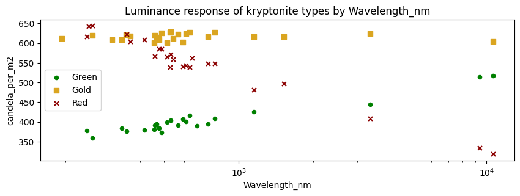

```python
plot_kryptonite()
```

```python
GT(krypt[
    (krypt.Wavelength_nm > 1500) &
    (krypt.Wavelength_nm < 10000)]
 .sort_values('Wavelength_nm'))
```

| Laser_type_kw | Subtype | Wavelength_nm | Kryptonite_type | candela_per_m2 |
| --- | --- | --- | --- | --- |
| Helium–neon |  | 1520.0 | Green |  |
| Helium–neon |  | 1520.0 | Red | 497.592 |
| Helium–neon |  | 1520.0 | Gold | 616.262 |
| Helium–neon |  | 3391.3 | Green | 444.054 |
| Helium–neon |  | 3391.3 | Red | 409.322 |
| Helium–neon |  | 3391.3 | Gold | 624.755 |
| CO2 |  | 9400.0 | Green | 514.181 |
| CO2 |  | 9400.0 | Red | 334.444 |
| CO2 |  | 9400.0 | Gold |  |

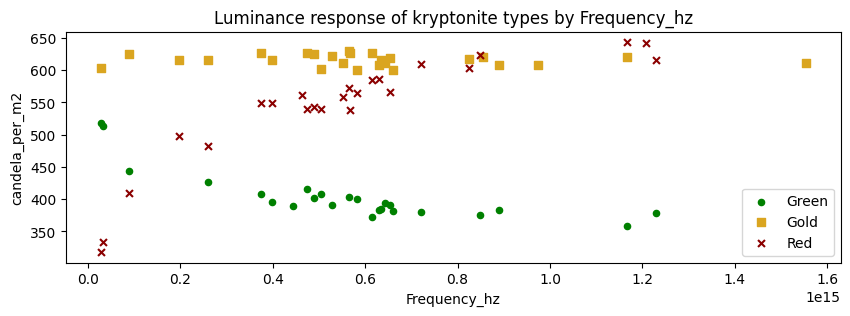

```python
λ = krypt.Wavelength_nm / 10**9   # Wavelength in meters
c = 299_792_458                   # Speed of light in m/s
krypt['Frequency_hz'] = c/λ

# Plot frequency vs luminance
plot_kryptonite(df=krypt, logx=False, independent='Frequency_hz')
```

```python
# Only perform the polyfit on the non-missing data
kr_vals = (krypt[krypt.candela_per_m2.notnull()]
           .sort_values('Frequency_hz'))

# Do a fit for each kryptonite color
for color in ('Red', 'Green', 'Gold'):
    # Limit to the color being fit
    kcolor = kr_vals.loc[kr_vals.Kryptonite_type == color]
    x = kcolor["Frequency_hz"]
    y = kcolor["candela_per_m2"]
    coef2, coef1, offset = np.polyfit(x, y, deg=2)

    # Print out the discovered coefficients
    print(f"{color:>5s} (hz → nit): "
          f"{coef2:.1e}*x^2 + {coef1:.1e}*x + {offset:.1e}")

    # Use coefficients to fill missing values
    kmissing = krypt.loc[krypt.candela_per_m2.isnull() &
                         (krypt.Kryptonite_type == color)]
    x = kmissing.Frequency_hz
    krypt.loc[x.index, 'candela_per_m2'] = (
                            coef2*x**2 + coef1*x + offset)
```

```
  Red (hz → nit): -2.6e-28*x^2 + 5.5e-13*x + 3.5e+02
Green (hz → nit): 1.4e-28*x^2 + -2.7e-13*x + 5.0e+02
 Gold (hz → nit): -4.1e-30*x^2 + 2.8e-15*x + 6.2e+02
```

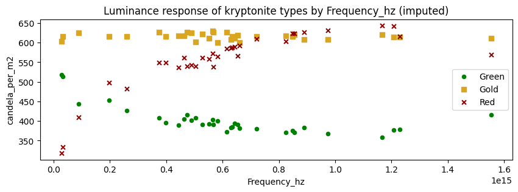

```python
plot_kryptonite(df=krypt, logx=False, imputed=True,
                independent='Frequency_hz')
```

# Sampling

```python
GT(
    humans.sample(8).round(2)
  ).tab_header(title="Measurements of 25,000 humans")
```

Measurements of 25,000 humans

| Height | Weight |
| --- | --- |
| 167.07 | 56.5 |
| 185.01 | 65.07 |
| 169.25 | 52.83 |
| 167.99 | 54.56 |
| 173.77 | 65.72 |
| 168.98 | 57.61 |
| 175.68 | 58.45 |
| 174.97 | 55.84 |

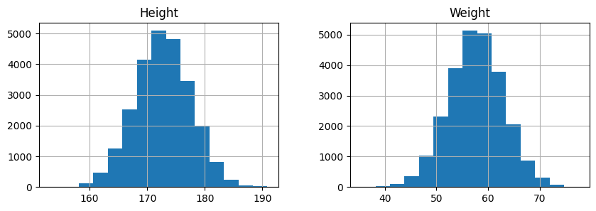

```python
humans.hist(figsize=(10,3), bins=15);
```

## Undersampling

```python
GT(cars.sample(10))
```

| price_buy | price_maintain | door | passengers | trunk | safety | rating |
| --- | --- | --- | --- | --- | --- | --- |
| 0 | 3 | 2 | 6 | 0 | 2 | Unacceptable |
| 2 | 1 | 5 | 6 | 1 | 2 | Acceptable |
| 2 | 3 | 5 | 4 | 1 | 2 | Unacceptable |
| 2 | 1 | 5 | 2 | 0 | 0 | Unacceptable |
| 2 | 1 | 5 | 4 | 0 | 2 | Acceptable |
| 2 | 1 | 3 | 2 | 1 | 1 | Unacceptable |
| 2 | 1 | 4 | 2 | 0 | 1 | Unacceptable |
| 2 | 3 | 4 | 4 | 0 | 0 | Unacceptable |
| 1 | 2 | 2 | 2 | 2 | 1 | Unacceptable |
| 2 | 3 | 2 | 6 | 0 | 1 | Unacceptable |

```python
GT(cars["rating"].value_counts())
```

| rating | count |
| --- | --- |
| Acceptable | 384 |
| Very Good | 65 |
| Good | 69 |
| Unacceptable | 1210 |

If three things hold, undersampling is unproblematic:

- We have a great many rows in the data set;
- Even the uncommon classes have a reasonable number of samples;
- The parameter space is well covered by the samples.

```python
unacc = cars.filter(pl.col("rating") == "Unacceptable").sample(100)
acc = cars.filter(pl.col("rating") == "Acceptable").sample(100)
good = cars.filter(pl.col("rating") == "Good")
vgood = cars.filter(pl.col("rating") == "Very Good")
samples = pl.concat([unacc, acc, good, vgood])
GT(samples["rating"].value_counts(sort=True))
```

| rating | count |
| --- | --- |
| Unacceptable | 100 |
| Acceptable | 100 |
| Good | 69 |
| Very Good | 65 |

## Oversampling

```python
large_sample = pl.concat(
    [part.sample(500, with_replacement=True)
     for part in cars.partition_by(by="rating")]
)
GT(large_sample.sample(8))
```

| price_buy | price_maintain | door | passengers | trunk | safety | rating |
| --- | --- | --- | --- | --- | --- | --- |
| 2 | 2 | 4 | 2 | 2 | 0 | Unacceptable |
| 1 | 1 | 5 | 4 | 0 | 2 | Acceptable |
| 0 | 0 | 3 | 4 | 0 | 2 | Good |
| 1 | 2 | 2 | 6 | 2 | 1 | Acceptable |
| 3 | 0 | 2 | 6 | 2 | 0 | Unacceptable |
| 0 | 2 | 3 | 6 | 2 | 2 | Very Good |
| 2 | 1 | 2 | 4 | 2 | 2 | Acceptable |
| 0 | 3 | 4 | 4 | 0 | 2 | Acceptable |

```python
# Only define the feature and target matrices, use in next cell
from imblearn.over_sampling import SMOTE

# Divide data frame into X features and y target
X = cars.drop("rating", axis=1)
y = cars["rating"]

# Create the resamples features/target
X_res, y_res = SMOTE(k_neighbors=4).fit_resample(X, y)
```

```python
cars.rating.value_counts()
```

```
rating
Unacceptable    1210
Acceptable       384
Good              69
Very Good         65
Name: count, dtype: int64
```

```python
synth_cars = X_res.copy()
synth_cars['rating'] = y_res
GT(synth_cars.sample(8, random_state=2))
```

| price_buy | price_maintain | door | passengers | trunk | safety | rating |
| --- | --- | --- | --- | --- | --- | --- |
| 2 | 2 | 5 | 6 | 0 | 0 | Unacceptable |
| 0 | 3 | 2 | 6 | 0 | 1 | Unacceptable |
| 2 | 1 | 4 | 6 | 2 | 1 | Acceptable |
| 2 | 3 | 5 | 2 | 0 | 0 | Unacceptable |
| 0 | 0 | 4 | 4 | 2 | 1 | Good |
| 0 | 0 | 5 | 4 | 0 | 2 | Good |
| 0 | 0 | 4 | 6 | 2 | 2 | Very Good |
| 2 | 3 | 5 | 6 | 2 | 0 | Unacceptable |

```python
synth_cars.rating.value_counts()
```

```
rating
Unacceptable    1210
Acceptable      1210
Very Good       1210
Good            1210
Name: count, dtype: int64
```

```python
cars.iloc[:, :6] = cars.iloc[:, :6].astype(float)
GT(cars.head())
```

| price_buy | price_maintain | door | passengers | trunk | safety | rating |
| --- | --- | --- | --- | --- | --- | --- |
| 1.0 | 0.0 | 3.0 | 6.0 | 0.0 | 0.0 | Unacceptable |
| 2.0 | 2.0 | 3.0 | 6.0 | 2.0 | 1.0 | Acceptable |
| 2.0 | 2.0 | 5.0 | 2.0 | 1.0 | 1.0 | Unacceptable |
| 0.0 | 1.0 | 3.0 | 2.0 | 2.0 | 1.0 | Unacceptable |
| 2.0 | 1.0 | 5.0 | 2.0 | 0.0 | 1.0 | Unacceptable |

```python
# Divide data frame into X features and y target
X = cars.drop('rating', axis=1)
y = cars['rating']

# Create the resamples features/target
X_, y_ = SMOTE().fit_resample(X, y)
GT(pd.concat([X_, y_], axis=1).round(2).sample(6))
```

| price_buy | price_maintain | door | passengers | trunk | safety | rating |
| --- | --- | --- | --- | --- | --- | --- |
| 2.0 | 2.0 | 4.0 | 4.0 | 0.0 | 1.0 | Unacceptable |
| 0.0 | 0.0 | 3.0 | 6.0 | 0.0 | 0.0 | Unacceptable |
| 0.0 | 0.0 | 2.28 | 4.0 | 2.0 | 2.0 | Very Good |
| 0.0 | 0.0 | 3.02 | 6.0 | 2.0 | 1.0 | Good |
| 2.0 | 0.0 | 4.0 | 6.0 | 2.0 | 1.65 | Acceptable |
| 1.0 | 0.0 | 4.71 | 6.0 | 2.0 | 2.0 | Very Good |

# Denouement

*Never answer the question that is asked of you. Answer the question that you wish had been asked of you.*

–Robert McNamara